# sparse data structures in tidymodels

J.H AHN

2022 2 15

## Why sparse data

This example comes from tidyverse blog(https://www.tidyverse.org/blog/2020/11/tidymodels-sparse-support)

일부 주제 영역에서는 데이터를 분석 또는 모델링에 적합한 표현으로 변환한 후 많은 0을 갖는 것이 일반적입니다. 텍스트 데이터가 그러한 예입니다. 아마존 고급 식품 리뷰의 `small_fine_food` 데이터 세트에는 인간이 읽고 이해할 수 있는 칼럼 `review`가 포함되어 있습니다.

```r
library(tidyverse)
library(tidymodels)
data("small_fine_foods")

training_data
```

```
## # A tibble: 4,000 x 3
##    product    review                                                       score
##    <chr>      <chr>                                                        <fct>
##  1 B000J0LSBG "this stuff is  not stuffing  its  not good at all  save yo~ other
##  2 B000EYLDYE "I absolutely LOVE this dried fruit.  LOVE IT.  Whenever I ~ great
##  3 B0026LIO9A "GREAT DEAL, CONVENIENT TOO.  Much cheaper than WalMart and~ great
##  4 B00473P8SK "Great flavor, we go through a ton of this sauce! I discove~ great
##  5 B001SAWTNM "This is excellent salsa/hot sauce, but you can get it for ~ great
##  6 B000FAG90U "Again, this is the best dogfood out there.  One suggestion~ great
##  7 B006BXTCEK "The box I received was filled with teas, hot chocolates, a~ other
##  8 B002GWH5OY "This is delicious coffee which compares favorably with muc~ great
##  9 B003R0MFYY "Don't let these little tiny cans fool you.  They pack a lo~ great
## 10 B001EO5ZXI "One of the nicest, smoothest cup of chai I've made. Nice m~ great
## # ... with 3,990 more rows
```

반면에 컴퓨터는 대부분의 모델링에 사용할 수 있도록 `review` 변수를 사전 처리하고 변환해야 합니다. 일반적으로 텍스트를 토큰화하고 단어 빈도를 찾고 아마도 tf-idf를 계산해야 합니다. 이 전처리 결과를 저장하는 데 사용할 수 있는 다양한 구조가 있습니다. 탐색적 데이터 분석에 탁월한 길고 깔끔한 tibble에 결과를 보관할 수 있습니다.

```r
library(tidytext)

training_data %>%
  unnest_tokens(word, review)
```

```
## # A tibble: 296,385 x 3
##    product    score word
##    <chr>      <fct> <chr>
##  1 B000J0LSBG other this
##  2 B000J0LSBG other stuff
##  3 B000J0LSBG other is
##  4 B000J0LSBG other not
##  5 B000J0LSBG other stuffing
##  6 B000J0LSBG other its
##  7 B000J0LSBG other not
##  8 B000J0LSBG other good
##  9 B000J0LSBG other at
## 10 B000J0LSBG other all
## # ... with 296,375 more rows
```

```r
training_data %>%
  unnest_tokens(word, review) %>%
  count(product, word)
```

```
## # A tibble: 208,306 x 3
##    product    word        n
##    <chr>      <chr>   <int>
##  1 B0000691JF and         1
##  2 B0000691JF i           1
##  3 B0000691JF in          1
##  4 B0000691JF just        1
##  5 B0000691JF manner      1
##  6 B0000691JF ordered     1
##  7 B0000691JF prompt      1
##  8 B0000691JF the         1
##  9 B0000691JF usual       1
## 10 B0000691JF what        1
## # ... with 208,296 more rows
```

```r
training_data %>%
  unnest_tokens(word, review) %>%
  count(product, word) %>%
  bind_tf_idf(word, product, n)
```

```
## # A tibble: 208,306 x 6
##    product    word        n    tf   idf tf_idf
##    <chr>      <chr>   <int> <dbl> <dbl>  <dbl>
##  1 B0000691JF and         1   0.1 0.234 0.0234
##  2 B0000691JF i           1   0.1 0.262 0.0262
##  3 B0000691JF in          1   0.1 0.654 0.0654
##  4 B0000691JF just        1   0.1 1.54  0.154
##  5 B0000691JF manner      1   0.1 5.52  0.552
##  6 B0000691JF ordered     1   0.1 2.76  0.276
##  7 B0000691JF prompt      1   0.1 5.81  0.581
##  8 B0000691JF the         1   0.1 0.206 0.0206
##  9 B0000691JF usual       1   0.1 5.04  0.504
## 10 B0000691JF what        1   0.1 2.27  0.227
## # ... with 208,296 more rows
```

```r
tidy_review <- training_data %>%
  unnest_tokens(word, review) %>%
  count(product, word) %>%
  bind_tf_idf(word, product, n)

tidy_review
```

```
## # A tibble: 208,306 x 6
##    product    word        n    tf   idf tf_idf
##    <chr>      <chr>   <int> <dbl> <dbl>  <dbl>
##  1 B0000691JF and         1   0.1 0.234 0.0234
##  2 B0000691JF i           1   0.1 0.262 0.0262
##  3 B0000691JF in          1   0.1 0.654 0.0654
##  4 B0000691JF just        1   0.1 1.54  0.154
##  5 B0000691JF manner      1   0.1 5.52  0.552
##  6 B0000691JF ordered     1   0.1 2.76  0.276
##  7 B0000691JF prompt      1   0.1 5.81  0.581
##  8 B0000691JF the         1   0.1 0.206 0.0206
##  9 B0000691JF usual       1   0.1 5.04  0.504
## 10 B0000691JF what        1   0.1 2.27  0.227
## # ... with 208,296 more rows
```

또한 이러한 결과를 다음 단계가 모델링 또는 기계 학습 알고리즘일 때 적합한 wide format으로 변환할 수도 있습니다.

```r
tidy_review %>%
  select(product, word, tf_idf)
```

```
## # A tibble: 208,306 x 3
##    product    word    tf_idf
##    <chr>      <chr>    <dbl>
##  1 B0000691JF and     0.0234
##  2 B0000691JF i       0.0262
##  3 B0000691JF in      0.0654
##  4 B0000691JF just    0.154
##  5 B0000691JF manner  0.552
##  6 B0000691JF ordered 0.276
##  7 B0000691JF prompt  0.581
##  8 B0000691JF the     0.0206
##  9 B0000691JF usual   0.504
## 10 B0000691JF what    0.227
## # ... with 208,296 more rows
```

```r
tidy_review %>%
  select(product, word, tf_idf) %>%
  pivot_wider(names_from = word, names_prefix = "word_",
              values_from = tf_idf, values_fill = 0)
```

```
## # A tibble: 4,000 x 13,797
##    product    word_and  word_i word_in word_just word_manner word_ordered
##    <chr>         <dbl>   <dbl>   <dbl>     <dbl>       <dbl>        <dbl>
##  1 B0000691JF  0.0234  0.0262  0.0654     0.154        0.552        0.276
##  2 B000084EHL  0.00780 0       0          0            0            0
##  3 B000084EIQ  0.00177 0.00397 0.0198     0.0117       0            0
##  4 B000084EJO  0.00582 0.00489 0.00813    0            0            0
##  5 B000084EJY  0.00246 0.0166  0.0207     0.0162       0            0
##  6 B000084EKB  0.00334 0.00750 0.00935    0            0            0
##  7 B000084EKW  0.0114  0.00729 0.00909    0            0            0
##  8 B000084EVH  0.00768 0.0129  0          0            0            0
##  9 B000084F07  0.00976 0       0          0            0            0
## 10 B000087BJ4  0.0156  0       0          0            0            0
## # ... with 3,990 more rows, and 13,790 more variables: word_prompt <dbl>,
## #   word_the <dbl>, word_usual <dbl>, word_what <dbl>, word_a <dbl>,
## #   word_anymore <dbl>, word_chocolate <dbl>, word_coat <dbl>,
## #   word_dogfood <dbl>, word_ears <dbl>, word_fine <dbl>, word_for <dbl>,
## #   word_great <dbl>, word_hardly <dbl>, word_he <dbl>, word_health <dbl>,
## #   word_his <dbl>, word_hot <dbl>, word_is <dbl>, word_itching <dbl>,
## #   word_lab <dbl>, word_no <dbl>, word_of <dbl>, word_or <dbl>, ...
```

```r
wide_review <- tidy_review %>%
  select(product, word, tf_idf) %>%
  pivot_wider(names_from = word, names_prefix = "word_",
              values_from = tf_idf, values_fill = 0)

wide_review
```

```
## # A tibble: 4,000 x 13,797
##    product    word_and  word_i word_in word_just word_manner word_ordered
##    <chr>         <dbl>   <dbl>   <dbl>     <dbl>       <dbl>        <dbl>
##  1 B0000691JF  0.0234  0.0262  0.0654     0.154        0.552        0.276
##  2 B000084EHL  0.00780 0       0          0            0            0
##  3 B000084EIQ  0.00177 0.00397 0.0198     0.0117       0            0
##  4 B000084EJO  0.00582 0.00489 0.00813    0            0            0
##  5 B000084EJY  0.00246 0.0166  0.0207     0.0162       0            0
##  6 B000084EKB  0.00334 0.00750 0.00935    0            0            0
##  7 B000084EKW  0.0114  0.00729 0.00909    0            0            0
##  8 B000084EVH  0.00768 0.0129  0          0            0            0
##  9 B000084F07  0.00976 0       0          0            0            0
## 10 B000087BJ4  0.0156  0       0          0            0            0
## # ... with 3,990 more rows, and 13,790 more variables: word_prompt <dbl>,
## #   word_the <dbl>, word_usual <dbl>, word_what <dbl>, word_a <dbl>,
## #   word_anymore <dbl>, word_chocolate <dbl>, word_coat <dbl>,
## #   word_dogfood <dbl>, word_ears <dbl>, word_fine <dbl>, word_for <dbl>,
## #   word_great <dbl>, word_hardly <dbl>, word_he <dbl>, word_health <dbl>,
## #   word_his <dbl>, word_hot <dbl>, word_is <dbl>, word_itching <dbl>,
## #   word_lab <dbl>, word_no <dbl>, word_of <dbl>, word_or <dbl>, ...
```

정말많은 0이 있다! tibble을 사용하는 대신 이러한 결과를 모든 요소 대신 0이 아닌 요소만 추적하는 특수 데이터 구조인 희소 행렬(sparse matrix)로 변환할 수 있습니다.

```r
tidy_review %>% cast_dfm(document = product,
                         term = word,
                         value = tf_idf)
```

```
## Document-feature matrix of: 4,000 documents, 13,796 features (99.62% sparse) and 0 docvars.
##             features
## docs                 and           i          in       just    manner   ordered
##   B0000691JF 0.023414131 0.026233926 0.065440735 0.15429482 0.5521461 0.2764621
##   B000084EHL 0.007804710 0           0           0          0         0
##   B000084EIQ 0.001773798 0.003974837 0.019830526 0.01168900 0         0
##   B000084EJO 0.005817175 0.004888309 0.008129284 0          0         0
##   B000084EJY 0.002464645 0.016568796 0.020665495 0.01624156 0         0
##   B000084EKB 0.003344876 0.007495408 0.009348676 0          0         0
##             features
## docs            prompt         the     usual      what
##   B0000691JF 0.5809143 0.020579491 0.5035953 0.2268184
##   B000084EHL 0         0           0         0
##   B000084EIQ 0         0.006236209 0         0
##   B000084EJO 0         0.003834688 0         0.0140881
##   B000084EJY 0         0.002166262 0         0
##   B000084EKB 0         0.011759709 0         0
## [ reached max_ndoc ... 3,994 more documents, reached max_nfeat ... 13,786 more features ]
```

```r
sparse_review <- tidy_review %>%
  cast_dfm(document = product, term = word, value = tf_idf)
```

```r
class(sparse_review)
```

```
## [1] "dfm"
## attr(,"package")
## [1] "quanteda"
```

텍스트 데이터의 경우 일반적으로 이 문서 기능 행렬은 0이 많이 포함된 매우 희소합니다. 대부분의 문서에는 대부분의 단어가 포함되어 있지 않습니다. vanilla `matrix`이나 `data.frame`과 같은 것 대신에 이런 종류의 특수 구조를 사용함으로써 우리는 두 가지 이점을 확보할 수 있습니다.

- 희소 데이터용으로 구축된 모든 특수 모델 알고리즘에서 얻은 속도를 활용할 수 있습니다.
- 이 개체에 필요한 메모리 양이 크게 줄어듭니다.

얼마나 큰 메모리 변화에 대해 이야기하고 있습니까?

```r
lobstr::obj_sizes(wide_review, sparse_review)
```

```
## * 443,539,792 B
## *   3,581,120 B
```

## A blueprint for sparse models

hardhat, parsnip 및 tune의 최신 릴리스 이전에는 tidymodels 내에서 희소 데이터 구조에 대한 지원이 없었습니다. 이제 sparse data를 사용하기 위한 hardhat blueprint를 지정할 수 있습니다.

```r
library(hardhat)

default_recipe_blueprint(composition = "dgCMatrix")
```

```
## Recipe blueprint:
##
## # Predictors: 0
##   # Outcomes: 0
##    Intercept: FALSE
## Novel Levels: FALSE
##  Composition: dgCMatrix
```

`dgCMatrix` 구성은 Matrix 패키지에 있으며 R에서 모델링할 때 희소 숫자 행렬에 대한 가장 표준적인 클래스입니다. (`composition = "matrix"`를 사용하여 dense matrix composition (조밀한 행렬 구성)을 지정할 수도 있습니다.)

```r
sparse_bp <- default_recipe_blueprint(composition = "dgCMatrix")

class(sparse_bp)
```

```
## [1] "default_recipe_blueprint" "recipe_blueprint"
## [3] "hardhat_blueprint"
```

## Workflows and sparsity

blueprint는 데이터를 처리하기 위해 hardhat 기능에 의해 hood 아래에서 사용됩니다. sparse blueprint를 사용하여 모델을 맞출 준비를 하기 위해 사전 처리 recipe를 설정할 수 있습니다.

```r
library(textrecipes)

recipe(score ~ review, data = training_data) %>% prep() %>% juice()
```

```
## # A tibble: 4,000 x 2
##    review                                                                  score
##    <fct>                                                                   <fct>
##  1 "this stuff is  not stuffing  its  not good at all  save your money"    other
##  2 "I absolutely LOVE this dried fruit.  LOVE IT.  Whenever I have a crav~ great
##  3 "GREAT DEAL, CONVENIENT TOO.  Much cheaper than WalMart and I don't ne~ great
##  4 "Great flavor, we go through a ton of this sauce! I discovered it in a~ great
##  5 "This is excellent salsa/hot sauce, but you can get it for $29.95 from~ great
##  6 "Again, this is the best dogfood out there.  One suggestion:  the bag ~ great
##  7 "The box I received was filled with teas, hot chocolates, and none of ~ other
##  8 "This is delicious coffee which compares favorably with much higher pr~ great
##  9 "Don't let these little tiny cans fool you.  They pack a lot of food. ~ great
## 10 "One of the nicest, smoothest cup of chai I've made. Nice mix of spice~ great
## # ... with 3,990 more rows
```

```r
recipe(score ~ review, data = training_data) %>%
  step_tokenize(review) %>%
  prep() %>% juice()
```

```
## # A tibble: 4,000 x 2
##          review score
##       <tknlist> <fct>
##  1  [13 tokens] other
##  2  [94 tokens] great
##  3 [104 tokens] great
##  4  [36 tokens] great
##  5  [19 tokens] great
##  6  [27 tokens] great
##  7  [83 tokens] other
##  8  [53 tokens] great
##  9  [55 tokens] great
## 10  [45 tokens] great
## # ... with 3,990 more rows
```

```r
recipe(score ~ review, data = training_data) %>%
  step_tokenize(review) %>%
  step_stopwords(review) %>%
  prep() %>% juice()
```

```
## # A tibble: 4,000 x 2
##         review score
##      <tknlist> <fct>
##  1  [5 tokens] other
##  2 [54 tokens] great
##  3 [66 tokens] great
##  4 [20 tokens] great
##  5 [11 tokens] great
##  6 [12 tokens] great
##  7 [52 tokens] other
##  8 [30 tokens] great
##  9 [31 tokens] great
## 10 [24 tokens] great
## # ... with 3,990 more rows
```

```r
recipe(score ~ review, data = training_data) %>%
  step_tokenize(review) %>%
  step_stopwords(review) %>%
  step_tokenfilter(review, max_tokens = 1e3) %>%
  prep() %>% juice()
```

```
## # A tibble: 4,000 x 2
##         review score
##      <tknlist> <fct>
##  1  [4 tokens] other
##  2 [41 tokens] great
##  3 [35 tokens] great
##  4 [17 tokens] great
##  5  [7 tokens] great
##  6  [8 tokens] great
##  7 [39 tokens] other
##  8 [22 tokens] great
##  9 [25 tokens] great
## 10 [19 tokens] great
## # ... with 3,990 more rows
```

```r
recipe(score ~ review, data = training_data) %>%
  step_tokenize(review) %>%
  step_stopwords(review) %>%
  step_tokenfilter(review, max_tokens = 1e3) %>%
  step_tfidf(review) %>%
  prep() %>% juice()
```

```
## # A tibble: 4,000 x 1,001
##    score tfidf_review_1 tfidf_review_10 tfidf_review_100 tfidf_review_12
##    <fct>          <dbl>           <dbl>            <dbl>           <dbl>
##  1 other              0               0            0                   0
##  2 great              0               0            0                   0
##  3 great              0               0            0.129               0
##  4 great              0               0            0                   0
##  5 great              0               0            0                   0
##  6 great              0               0            0                   0
##  7 other              0               0            0                   0
##  8 great              0               0            0                   0
##  9 great              0               0            0                   0
## 10 great              0               0            0                   0
## # ... with 3,990 more rows, and 996 more variables: tfidf_review_15 <dbl>,
## #   tfidf_review_16 <dbl>, tfidf_review_2 <dbl>, tfidf_review_20 <dbl>,
## #   tfidf_review_24 <dbl>, tfidf_review_25 <dbl>, tfidf_review_3 <dbl>,
## #   tfidf_review_3.98 <dbl>, tfidf_review_30 <dbl>, tfidf_review_4 <dbl>,
## #   tfidf_review_40 <dbl>, tfidf_review_5 <dbl>, tfidf_review_50 <dbl>,
## #   tfidf_review_6 <dbl>, tfidf_review_7 <dbl>, tfidf_review_8 <dbl>,
## #   tfidf_review_9 <dbl>, tfidf_review_able <dbl>, ...
```

```r
text_rec <-
  recipe(score ~ review, data = training_data) %>%
  step_tokenize(review) %>%
  step_stopwords(review) %>%
  step_tokenfilter(review, max_tokens = 1e3) %>%
  step_tfidf(review)
```

```r
lasso_spec <-
  logistic_reg(penalty = 0.02, mixture = 1) %>%
  set_engine("glmnet")
```

glmnet 패키지의 정규화된 모델링은 희소 데이터에 대해 특수화된 접근 방식을 사용하는 알고리즘의 한 예입니다. `set_engine("glmnet")`을 사용하여 조밀한 데이터를 전달하면 기본 모델은 한 가지 접근 방식을 사용하지만 희소 행렬을 전달할 경우 희소 데이터를 위해 특별히 구축된 다른 더 빠른 접근 방식을 사용합니다. 일반적으로 glmnet과 같은 정규화된 모델을 피팅하기 전에 `step_normalize()`를 사용하여 예측자를 센터링 및 스케일링하는 것이 좋습니다. 그러나 이렇게 하면 더 이상 0과 희소 데이터가 모두 없게 됩니다. 대신 tf-idf를 사용하여 이러한 텍스트 예측자를 “정규화”하여 모두 동일한 척도에 있도록 할 수 있습니다.

하나는 sparse blueprint를 사용하고 다른 하나는 기본 동작을 사용하는 두 개의 워크플로를 함께 구성해 보겠습니다.

```r
wf_sparse <-
  workflow() %>%
  add_recipe(text_rec, blueprint = sparse_bp) %>%
  add_model(lasso_spec)

wf_default <-
  workflow() %>%
  add_recipe(text_rec) %>%
  add_model(lasso_spec)
```

## Comparing model results

이제 `fit_resamples()`를 사용하여 이 모델이 두 옵션에 얼마나 잘 맞는지 추정하고 두 옵션 모두에 대한 성능을 측정해 보겠습니다.

```r
set.seed(123)

food_folds <- vfold_cv(training_data, v = 3)

food_folds
```

```
## #  3-fold cross-validation
## # A tibble: 3 x 2
##   splits              id
##   <list>              <chr>
## 1 <split [2666/1334]> Fold1
## 2 <split [2667/1333]> Fold2
## 3 <split [2667/1333]> Fold3
```

```r
results <-
  bench::mark(
  iterations = 10, check = FALSE,
  sparse = fit_resamples(wf_sparse, food_folds),
  default = fit_resamples(wf_default, food_folds)
)
```

결과를 보면 sparse blueprint를 사용한는 것이 거의 10배 이상 빠르다는 것을 알 수 있다.

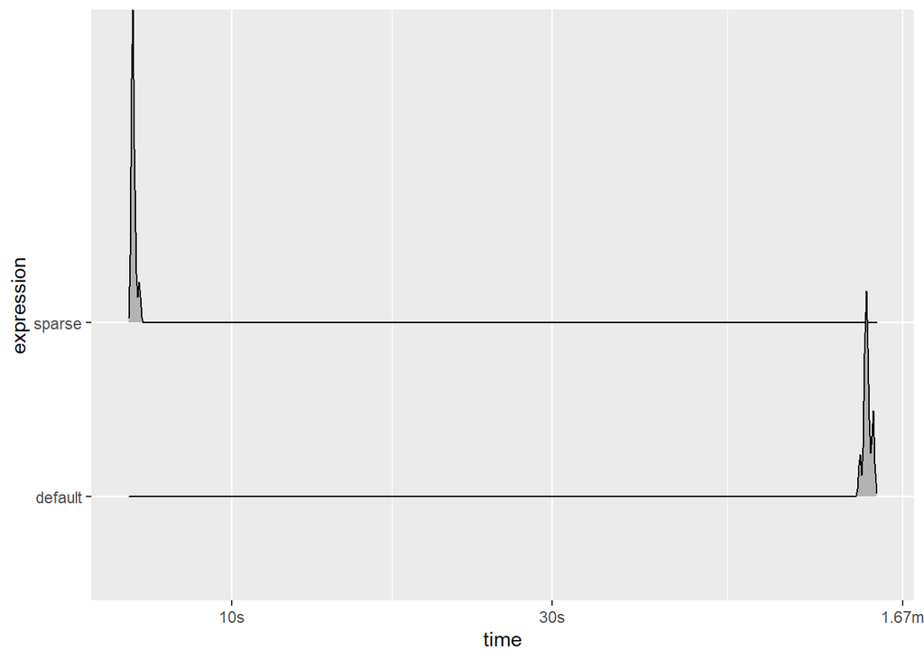

```r
autoplot(results, type = "ridge")
```

```r
fit_resamples(wf_sparse, food_folds) %>%
  collect_metrics()
```

```
## # A tibble: 2 x 6
##   .metric  .estimator  mean     n std_err .config
##   <chr>    <chr>      <dbl> <int>   <dbl> <chr>
## 1 accuracy binary     0.715     3 0.00399 Preprocessor1_Model1
## 2 roc_auc  binary     0.797     3 0.00598 Preprocessor1_Model1
```

```r
fit_resamples(wf_default, food_folds) %>%
  collect_metrics()
```

```
## # A tibble: 2 x 6
##   .metric  .estimator  mean     n std_err .config
##   <chr>    <chr>      <dbl> <int>   <dbl> <chr>
## 1 accuracy binary     0.715     3 0.00399 Preprocessor1_Model1
## 2 roc_auc  binary     0.797     3 0.00598 Preprocessor1_Model1
```

## Current limits

Tidymodels에서 희소 데이터 구조에 대한 지원은 전처리 recipe에서 시작하여 피팅 및 튜닝 프로세스 전반에 걸쳐 계속됩니다. 우리는 일반적으로 이 텍스트 분석 예제에서 볼 수 있는 것처럼 recipe에 대한 입력이 데이터 프레임이 될 것으로 예상하고, 예를 들어 `parsnip::fit_xy()`를 사용하여 희소 행렬로 시작하기 위한 Tidymodels 내 지원은 매우 제한적입니다.

현재 parsnip에는 희소 데이터 인코딩을 지원하는 세 가지 모델이 있습니다.

- 선형 및 로지스틱 회귀(다항 회귀 포함)를 위한 glmnet 엔진,
- 부스트 트리를 위한 XGBoost 엔진 및
- 랜덤 포레스트를 위한 레인저 엔진.

recipe 자체가 내부적으로 데이터를 처리하는 방식에 이질성이 있습니다. 이것이 `wf_sparse`를 `wf_default`와 비교할 때 메모리 사용이 크게 감소하지 않는 이유입니다. textrecipes[^https://textrecipes.tidymodels.org/] 패키지는 희소 데이터에 대해 메모리 효율적인 tokenlist[^https://textrecipes.tidymodels.org/reference/tokenlist.html] 이라는 아이디어를 내부적으로 채택하지만 다른 recipe 단계는 조밀한 tibble 구조의 데이터를 처리할 수 있습니다. 모델링 프로젝트의 메모리 요구 사항을 고려할 때 이러한 현재 제한을 염두에 두십시오!